# Practical Machine Learning Course Project

James Whitehead

28 January 2017

# Synopsis

The purpose of the project is to predict the manner in which participants perform barbell lifts. Six participants performed the lifts correctly and incorrectly in five different ways. Accelerometers were fitted on the belt, forearm, arm, and dumbell of each participant, and it is data from these that are used to predict the activity.

The data for this project come from: http://groupware.les.inf.puc-rio.br/har.

# Data cleaning and splitting

First, read in the training and testing data, removing columns that predominantly contain missing values. Also remove the first 7 columns as they don’t contain accelerometer data.

```r
library(caret); library(rpart); library(rattle); library(rpart.plot)
library(randomForest)
training <- read.csv("pml-training.csv", na.strings = c("", "NA"))
training <- training[,colSums(is.na(training))==0]
testing <- read.csv("pml-testing.csv")
training2 <- training[,-c(1:7)]
```

Now split the training data into subsets including a validation data set for testing the models.

```r
set.seed(147)
inTrain <- createDataPartition(training2$classe, p=0.75, list=FALSE)
trainSet <- training2[inTrain,]
validSet <- training2[-inTrain,]
```

# Prediction

First try classification trees.

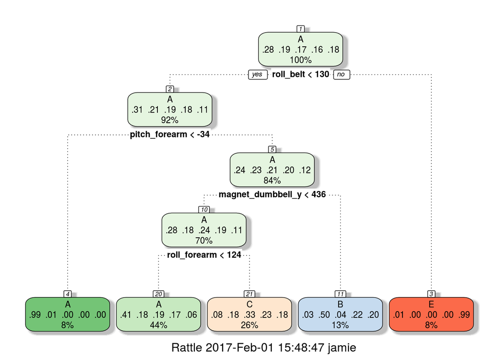

```r
modTREE <- train(classe~., trainSet, method="rpart")
predTREE <- predict(modTREE, validSet)
fancyRpartPlot(modTREE$finalModel)
```

```r
confusionMatrix(validSet$classe, predTREE)
```

```
## Confusion Matrix and Statistics
##
##           Reference
## Prediction    A    B    C    D    E
##          A 1257   31  102    0    5
##          B  405  318  226    0    0
##          C  389   27  439    0    0
##          D  366  141  297    0    0
##          E  128  112  248    0  413
##
## Overall Statistics
##
##                Accuracy : 0.4949
##                  95% CI : (0.4808, 0.509)
##     No Information Rate : 0.519
##     P-Value [Acc > NIR] : 0.9996
##
##                   Kappa : 0.34
##  Mcnemar's Test P-Value : NA
##
## Statistics by Class:
##
##                      Class: A Class: B Class: C Class: D Class: E
## Sensitivity            0.4939  0.50556  0.33460       NA  0.98804
## Specificity            0.9415  0.85240  0.88419   0.8361  0.89122
## Pos Pred Value         0.9011  0.33509  0.51345       NA  0.45838
## Neg Pred Value         0.6329  0.92137  0.78439       NA  0.99875
## Prevalence             0.5190  0.12826  0.26754   0.0000  0.08524
## Detection Rate         0.2563  0.06485  0.08952   0.0000  0.08422
## Detection Prevalence   0.2845  0.19352  0.17435   0.1639  0.18373
## Balanced Accuracy      0.7177  0.67898  0.60940       NA  0.93963
```

Clearly the accuracy is rather poor, with an out-of-sample error rate of 0.51. Better accuracy may be achieved using a random forests algorithm:

```r
modRF <- train(classe ~., data=trainSet, method="rf")
predRF <- predict(modRF, validSet)
confusionMatrix(validSet$classe, predRF)
```

```
## Confusion Matrix and Statistics
##
##           Reference
## Prediction    A    B    C    D    E
##          A 1393    1    0    0    1
##          B    6  941    2    0    0
##          C    0    2  851    2    0
##          D    0    0   11  793    0
##          E    0    0    1    3  897
##
## Overall Statistics
##
##                Accuracy : 0.9941
##                  95% CI : (0.9915, 0.996)
##     No Information Rate : 0.2853
##     P-Value [Acc > NIR] : < 2.2e-16
##
##                   Kappa : 0.9925
##  Mcnemar's Test P-Value : NA
##
## Statistics by Class:
##
##                      Class: A Class: B Class: C Class: D Class: E
## Sensitivity            0.9957   0.9968   0.9838   0.9937   0.9989
## Specificity            0.9994   0.9980   0.9990   0.9973   0.9990
## Pos Pred Value         0.9986   0.9916   0.9953   0.9863   0.9956
## Neg Pred Value         0.9983   0.9992   0.9965   0.9988   0.9998
## Prevalence             0.2853   0.1925   0.1764   0.1627   0.1831
## Detection Rate         0.2841   0.1919   0.1735   0.1617   0.1829
## Detection Prevalence   0.2845   0.1935   0.1743   0.1639   0.1837
## Balanced Accuracy      0.9976   0.9974   0.9914   0.9955   0.9989
```

This performed much better, with an accuracy of 0.9941, meaning an out-of-sample error rate of 0.0059. However, the random forests algorith is very time consuming, and scalability may be an issue.

Finally apply the prediction to the test set.

```r
predTEST <- predict(modRF, testing)
predTEST
```

```
##  [1] B A B A A E D B A A B C B A E E A B B B
## Levels: A B C D E
```